# Introduction to Data Science Project

Author

Joe Harrison, Maddy Puryear

The main set of slides to reference are created by Justin Post here at NC State

Additionally, [here](https://www.statlearning.com/) is the bible for data science, and covers essentially all of the main Machine Learning methods.

#### More resources:

There are an overwhelming amount of resources. I link these only because I like them, and they provide an excellent jumping off point if you are interested.

*Note that reading without actually implementing a project or summarizing what you have read is not going to be very helpful* (even though it feels like it is).

> - https://r-graph-gallery.com/ <- The go-to place for data visualization
> - https://happygitwithr.com/index.html <- How does git work???
> - https://arrow-user2022.netlify.app/ <- How do I do stuff with large datasets?
> - https://github.com/adam-p/markdown-here/wiki/Markdown-Cheatsheet <- Just a quick reference guide on markdown

Below are some other books:

> - https://stat545.com/index.html <- Intro to R
> - https://r4ds.hadley.nz/ <- Intro to R
> - https://dtkaplan.github.io/DataComputingEbook/index.html#table-of-contents <- Intro to R
> - https://do4ds.com/chapters/intro.html <- DevOps for production code in data science
> - https://edwinth.github.io/ADSwR/index.html <- Agile philosophy

```r
data <- read.csv(
  "C:\\Users\\tmp00403\\Downloads\\Hitters.csv"
)
summary(data)
```

```
   rownames             AtBat            Hits         HmRun
 Length:322         Min.   : 16.0   Min.   :  1   Min.   : 0.00
 Class :character   1st Qu.:255.2   1st Qu.: 64   1st Qu.: 4.00
 Mode  :character   Median :379.5   Median : 96   Median : 8.00
                    Mean   :380.9   Mean   :101   Mean   :10.77
                    3rd Qu.:512.0   3rd Qu.:137   3rd Qu.:16.00
                    Max.   :687.0   Max.   :238   Max.   :40.00

      Runs             RBI             Walks            Years
 Min.   :  0.00   Min.   :  0.00   Min.   :  0.00   Min.   : 1.000
 1st Qu.: 30.25   1st Qu.: 28.00   1st Qu.: 22.00   1st Qu.: 4.000
 Median : 48.00   Median : 44.00   Median : 35.00   Median : 6.000
 Mean   : 50.91   Mean   : 48.03   Mean   : 38.74   Mean   : 7.444
 3rd Qu.: 69.00   3rd Qu.: 64.75   3rd Qu.: 53.00   3rd Qu.:11.000
 Max.   :130.00   Max.   :121.00   Max.   :105.00   Max.   :24.000

     CAtBat            CHits            CHmRun           CRuns
 Min.   :   19.0   Min.   :   4.0   Min.   :  0.00   Min.   :   1.0
 1st Qu.:  816.8   1st Qu.: 209.0   1st Qu.: 14.00   1st Qu.: 100.2
 Median : 1928.0   Median : 508.0   Median : 37.50   Median : 247.0
 Mean   : 2648.7   Mean   : 717.6   Mean   : 69.49   Mean   : 358.8
 3rd Qu.: 3924.2   3rd Qu.:1059.2   3rd Qu.: 90.00   3rd Qu.: 526.2
 Max.   :14053.0   Max.   :4256.0   Max.   :548.00   Max.   :2165.0

      CRBI             CWalks           League            Division
 Min.   :   0.00   Min.   :   0.00   Length:322         Length:322
 1st Qu.:  88.75   1st Qu.:  67.25   Class :character   Class :character
 Median : 220.50   Median : 170.50   Mode  :character   Mode  :character
 Mean   : 330.12   Mean   : 260.24
 3rd Qu.: 426.25   3rd Qu.: 339.25
 Max.   :1659.00   Max.   :1566.00

    PutOuts          Assists          Errors          Salary
 Min.   :   0.0   Min.   :  0.0   Min.   : 0.00   Min.   :  67.5
 1st Qu.: 109.2   1st Qu.:  7.0   1st Qu.: 3.00   1st Qu.: 190.0
 Median : 212.0   Median : 39.5   Median : 6.00   Median : 425.0
 Mean   : 288.9   Mean   :106.9   Mean   : 8.04   Mean   : 535.9
 3rd Qu.: 325.0   3rd Qu.:166.0   3rd Qu.:11.00   3rd Qu.: 750.0
 Max.   :1378.0   Max.   :492.0   Max.   :32.00   Max.   :2460.0
                                                  NA's   :59
  NewLeague
 Length:322
 Class :character
 Mode  :character
```

## Project Goal:

By the end of this project, you should have a reproducable, visually appealing report.

Questions to address in your report include:

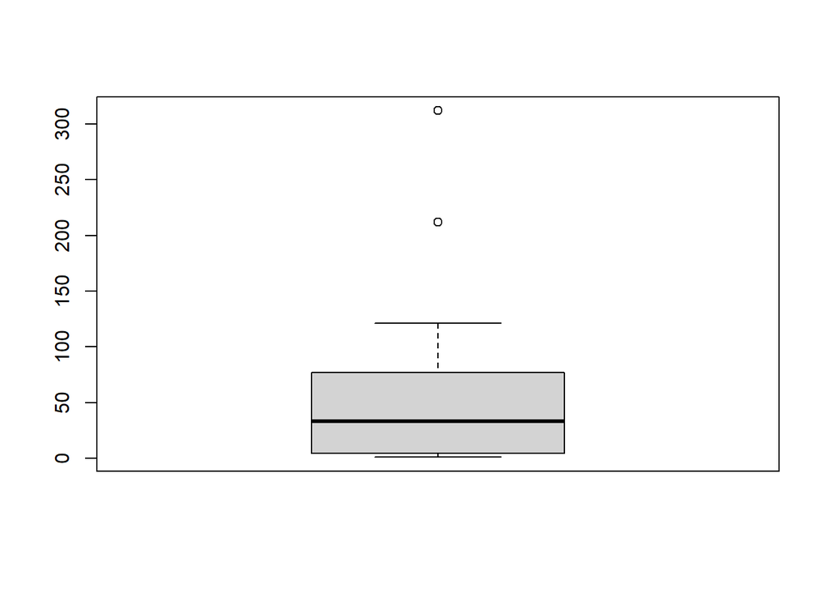

```r
new_league <- as.factor(data$NewLeague)
league <- as.factor(data$League)

switched_league <- which(new_league != league)
no_switch_league <- which(new_league == league)

career_homerun <- data$CHmRun
boxplot(career_homerun[switched_league])
```

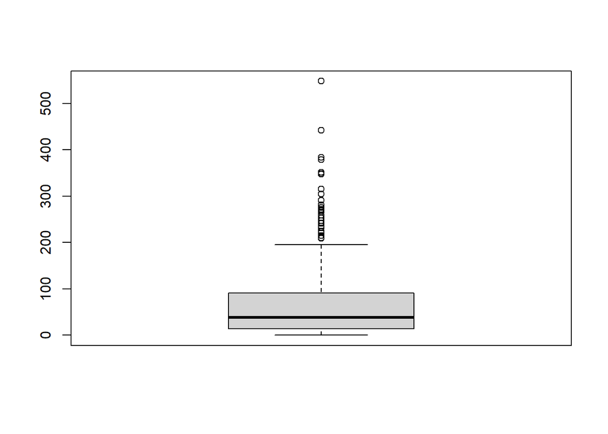

```r
boxplot(career_homerun[no_switch_league])
```

- Are there specific hitters that over/under performed relative to their salary? Mike Schmidt under preformed. He was being payed a bit over $2k however he was at the bat 20 times over the league and only hit one time. Meanwhile Kirby Puckett overpreformed, only being payed around $300, he had one of the highest number of hits out of everyone and preformed decent in the other areas as well

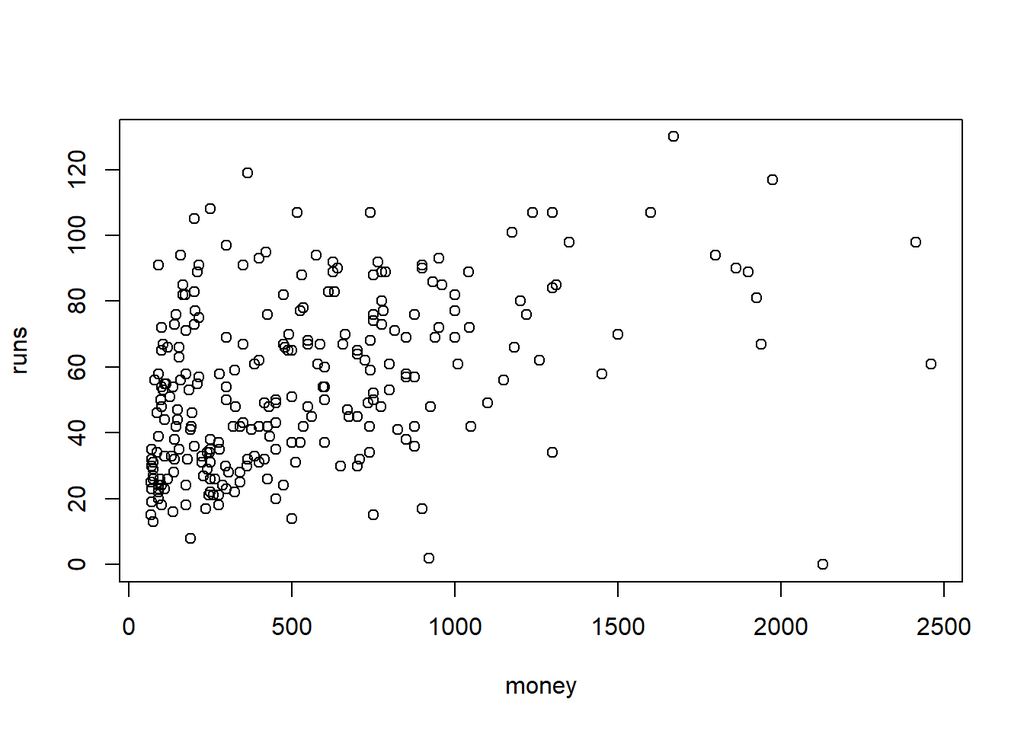

```r
library(dplyr)
money <- data$Salary
runs <- data$Runs

plot(money,runs)
```

```r
data |> filter(Salary > 2000 & Runs < 20)
```

```
       rownames AtBat Hits HmRun Runs RBI Walks Years CAtBat CHits CHmRun CRuns
1 -Mike Schmidt    20    1     0    0   0     0     2     41     9      2     6
  CRBI CWalks League Division PutOuts Assists Errors   Salary NewLeague
1    7      4      N        E      78     220      6 2127.333         N
```

```r
# data[data$Salary > 2000 & data$Runs < 20,]
# data |> filter(Salary < 500 & Runs > 100)
data[data$Salary < 500 & data$Runs > 100,]
```

```
            rownames AtBat Hits HmRun Runs RBI Walks Years CAtBat CHits CHmRun
142      -Joe Carter   663  200    29  108 121    32     4   1447   404     57
188   -Kirby Puckett   680  223    31  119  96    34     3   1928   587     35
228 -Oddibe McDowell   572  152    18  105  49    65     2    978   249     36
    CRuns CRBI CWalks League Division PutOuts Assists Errors Salary NewLeague
142   210  222     68      A        E     241       8      6    250         A
188   262  201     91      A        W     429       8      6    365         A
228   168   91    101      A        W     325      13      3    200         A
```

* Are players who spend longer in the league worth more? No because there is not a strong relationship between time spent in the league and salary earned.

```r
years <- data$Years
AtBat <- data$AtBat

summary(years)
```

```
   Min. 1st Qu.  Median    Mean 3rd Qu.    Max.
  1.000   4.000   6.000   7.444  11.000  24.000
```

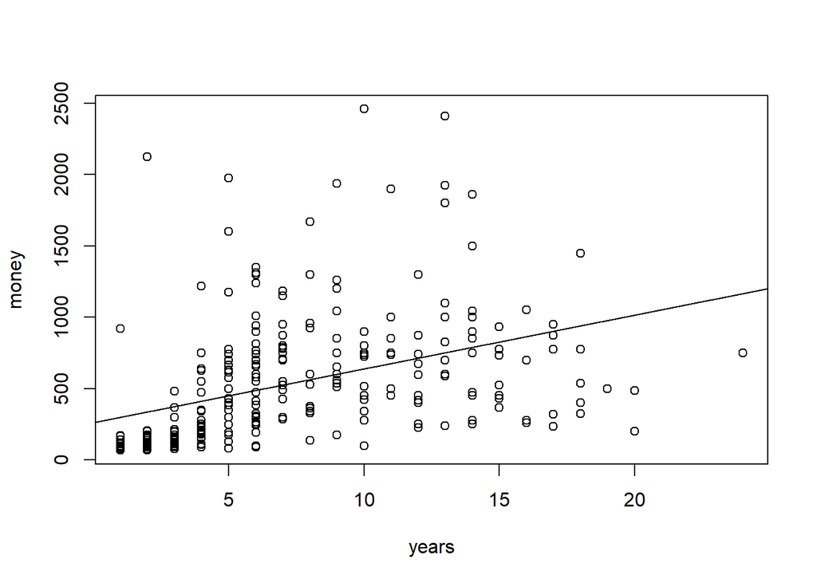

```r
plot(years, money)
abline(lm(money ~ years))
```

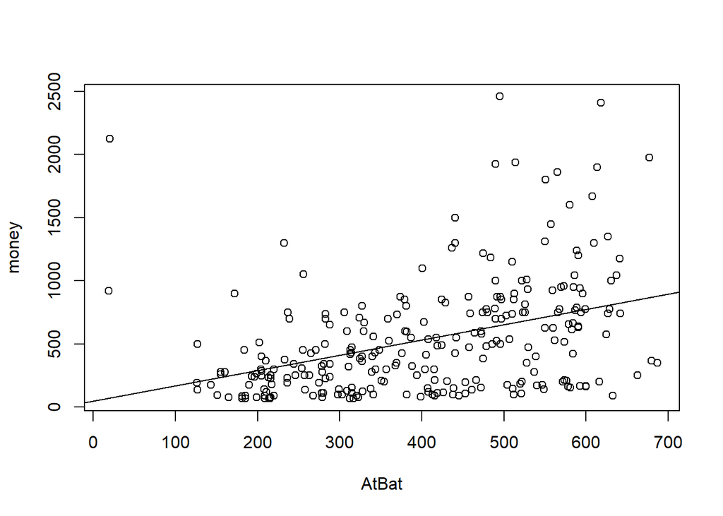

```r
plot(AtBat, money)
abline(lm(money ~ AtBat))
```

- Please explain in a paragraph any potential ethical issues that might arise from the creation of this report.

If people where to use this report for hiring players for their team, the data alone shows who over preforms and under preforms. This neglects other soft skills like communication and teamwork. Someone who over preforms might be bad at working in a team and instead focuses on self-service, whereas someone who under preforms might be more team oriented, helping the members of their team. Focusing only on data and not taking into account un measurable things could lead to detriment towards your team, being less able to work with each other. Another issue that may arrive is using only people who have switched leagues, and not players that are currently in this league, because of the data found previously. This would lead in a disproportionate people within a league or tying to get into a league.

### Stretch goals:

- See if you can predict whether a player will be paid higher or lower than the median salary.
- Are there any questions that come to your mind that you think are worthwhile to explore? Investigate! Explore!

## Skills you will acquire along the way:

- Understand the basics of manipulating data in R
- Understand the basics of Statistical Inference
- Gain experience grappling with randomness
- Interpret multivariate regression output
- Gain familiarity with common Machine Learning tools
- Learn the basics of plotting within R

## Start of project:

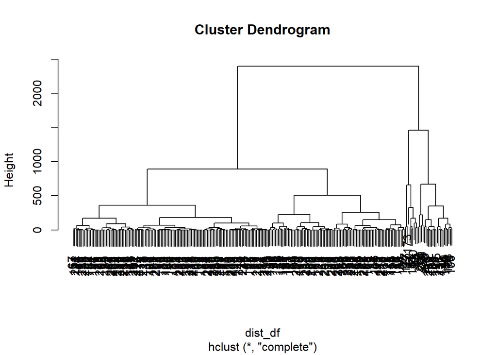

```r
# 6/25/26
# clustering data :0
library(cluster)
library(factoextra)
#hierarchy cluster
dist_df <- dist(na.omit(data$Salary))
hc <- hclust(dist_df)
plot(hc)
```

```r
#K means

newData <- data[,c(2:14, 17, 18, 19)]
# Factored columns (and salary) does not work because of non numbers

set.seed(240)
kmeans.re <- kmeans(newData, centers = 3, nstart = 20)
kmeans.re
```

```
K-means clustering with 3 clusters of sizes 54, 92, 176

Cluster means:
     AtBat      Hits    HmRun     Runs      RBI    Walks     Years    CAtBat
1 415.2778 109.51852 14.66667 54.77778 61.50000 48.07407 15.333333 6824.9259
2 439.2283 121.42391 11.63043 60.03261 54.10870 44.97826  9.217391 3409.2935
3 339.9148  87.75568  9.12500 44.95455 40.71591 32.61932  4.096591  969.7443
      CHits    CHmRun    CRuns     CRBI    CWalks  PutOuts   Assists   Errors
1 1887.5185 212.85185 953.7593 948.1481 716.61111 300.7593  83.37037 6.944444
2  927.6957  73.88043 458.1196 389.9239 317.35870 334.7174 136.70652 8.173913
3  248.7727  23.21023 124.3295 109.2330  90.35795 261.3807  98.56250 8.306818

Clustering vector:
  [1] 3 2 3 1 3 2 3 3 3 1 2 3 3 3 2 3 1 3 1 3 3 3 3 3 1 2 3 2 2 1 1 3 2 3 3 1 3
 [38] 3 1 3 3 1 2 3 2 3 3 3 1 2 1 3 3 2 1 3 3 2 2 2 3 1 3 3 3 1 3 3 3 2 1 3 1 1
 [75] 1 2 3 3 3 3 1 1 2 3 2 2 1 3 1 3 3 3 3 3 3 3 1 1 3 3 1 3 3 2 1 3 3 1 3 3 1
[112] 3 1 3 1 2 3 1 2 3 1 1 3 3 1 2 3 2 2 2 2 3 1 3 3 3 2 2 3 3 3 3 2 1 2 2 3 2
[149] 2 2 3 3 3 2 2 3 2 3 1 3 3 2 3 1 2 3 3 3 3 3 1 3 3 3 2 3 3 2 1 1 2 2 3 3 2
[186] 2 3 3 3 2 3 2 2 3 2 2 1 3 3 2 2 3 3 3 3 3 3 2 3 3 2 2 3 3 3 3 3 3 3 3 3 3
[223] 2 3 3 3 3 3 2 2 3 3 1 3 2 2 1 3 3 3 2 3 2 1 3 2 3 2 2 1 3 3 2 3 2 3 2 2 2
[260] 3 2 3 3 2 3 3 3 1 3 2 3 1 3 3 3 3 3 3 1 3 3 3 2 3 2 2 2 3 3 3 2 3 1 2 3 3
[297] 3 3 3 2 2 3 1 3 2 2 1 3 2 3 2 2 3 2 3 3 3 2 1 3 2 2

Within cluster sum of squares by cluster:
[1] 151433466  82793882  87802874
 (between_SS / total_SS =  84.0 %)

Available components:

[1] "cluster"      "centers"      "totss"        "withinss"     "tot.withinss"
[6] "betweenss"    "size"         "iter"         "ifault"
```

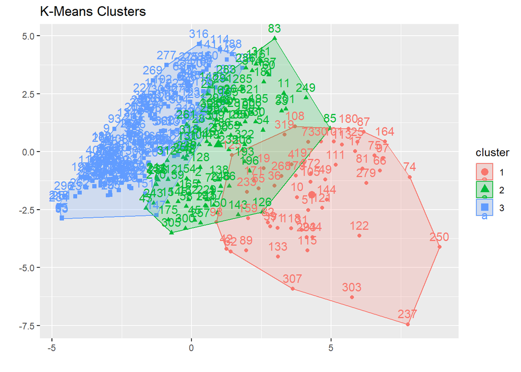

```r
#view(newData[1:26,])

fviz_cluster(kmeans.re, data = newData,
main = "K-Means Clusters",
xlab = "",
ylab = "")
```

```r
# Group 3 is grouped by low years
# Grooup 1 is grouped by high CHmrun
# Group 2 by CHits??
```

Correlations

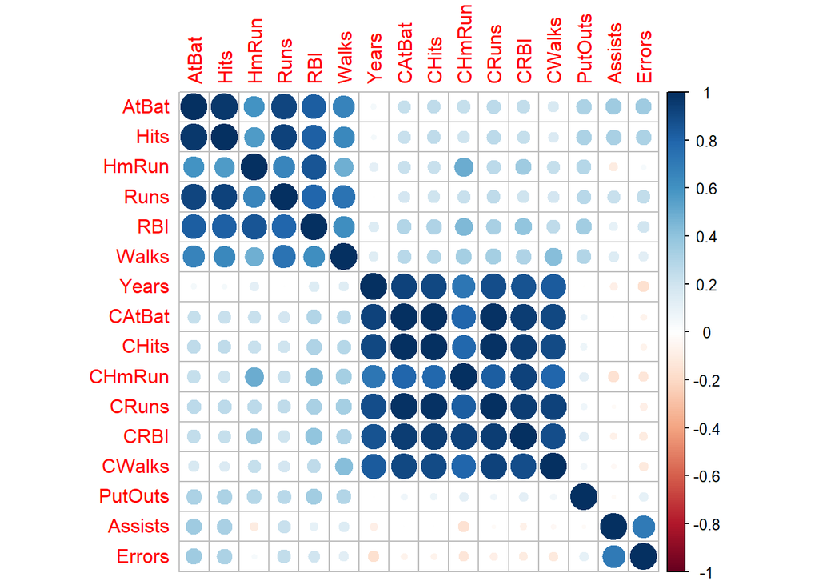

```r
#mcorrelation plot
library(corrplot)
corrplot(cor(newData))
```

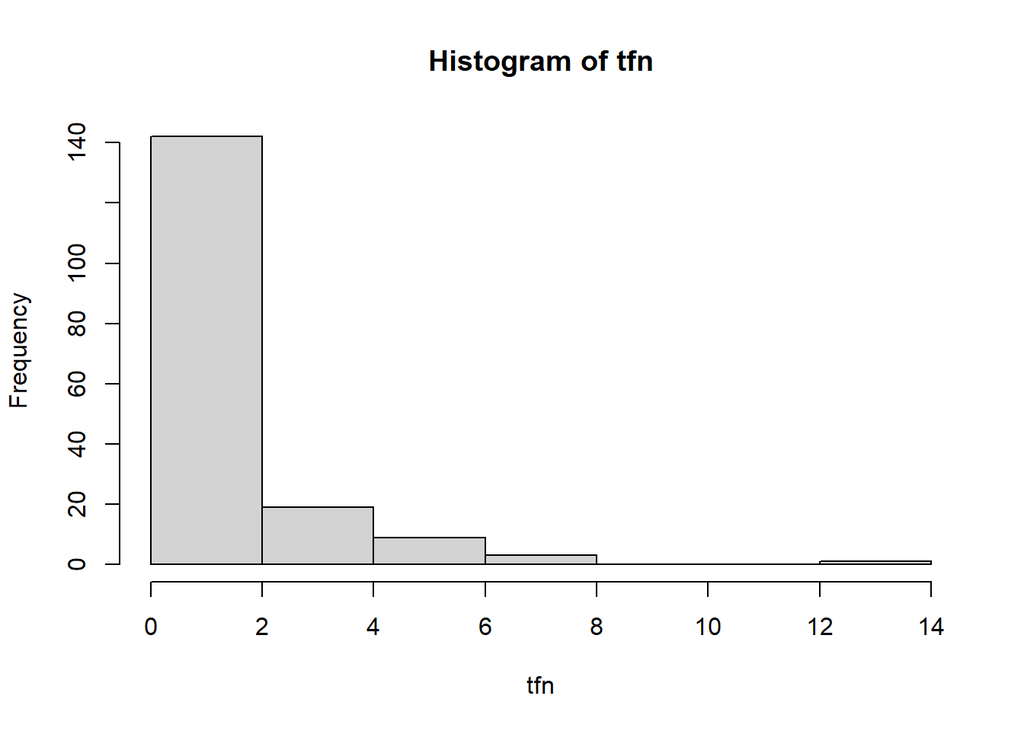

```r
#names, how often
library(tidyverse)
names <- data$rownames

names <- strsplit(names,' ')
names <- as.data.frame(names)
first_names <- names[1,]

first_names <- t(first_names)
tfn <- table(first_names)
# view(tfn)
hist(tfn)
```

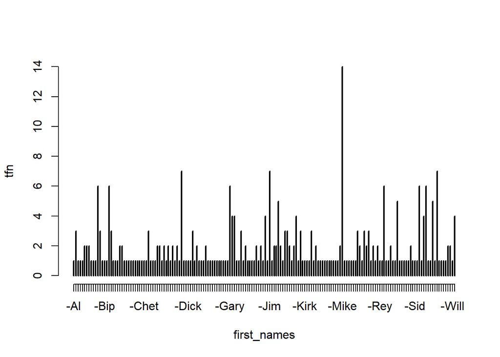

```r
plot(tfn)
```

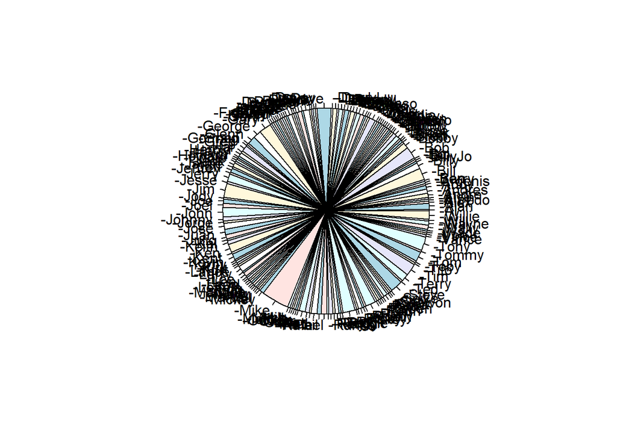

```r
pie(tfn)
```